# 知覺實驗概述

2020-11-01

## 單元說明

- 概述[心理計時學研究](https://scgeeker.github.io/EXPPSY_Opensci/chronometry.html)
- 體驗與探討經典知覺實驗
- 製作虛擬資料了解速度與正確率互補
- 運用psytoolkit重製實驗

## 心理計時學的起源

- 想法如何產生動作? by 謝伯讓
- 人類行為的個別差異
- 人類行為的測量誤差

## 人類行為的個別差異

[figure not shown]

法蘭西斯·高爾頓(1822-1911)

- 首位收集與分析巨量人類行為資料的科學家
- 奠定迴歸分析基本觀念與方法
- 啟發心理計量學的發展

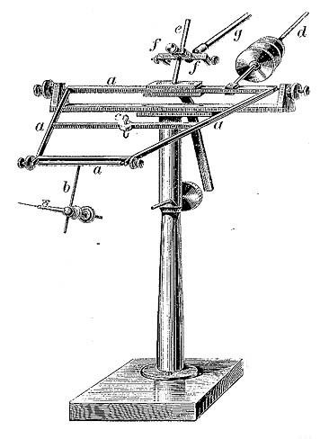

## 人類行為的測量誤差

[figure not shown]

內維爾·馬斯基林(1732-1811)，英國天文學家

## 人類行為的測量誤差

[figure not shown]

法蘭西斯庫斯·唐德斯(1818-1889)

- 設計相減法測量心理歷程
- 簡單反應時間 = 察覺 + 執行動作
- 選擇反應時間 = 察覺 + 區辨 + 選擇 + 執行動作
- 現代版相減法計時實驗(Deary, et al. 2011)

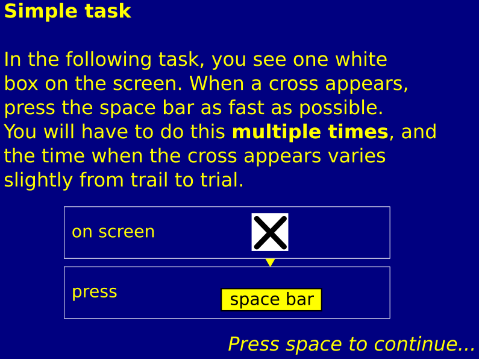

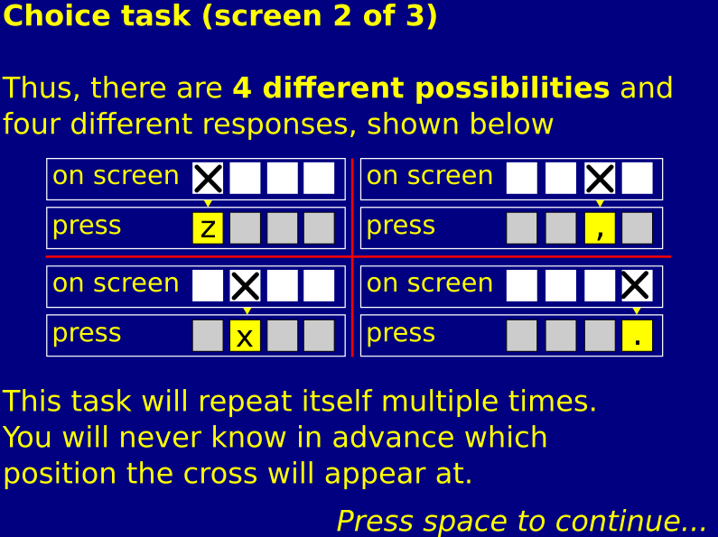

## 分析自己的反應資料

1.選取並複製資料

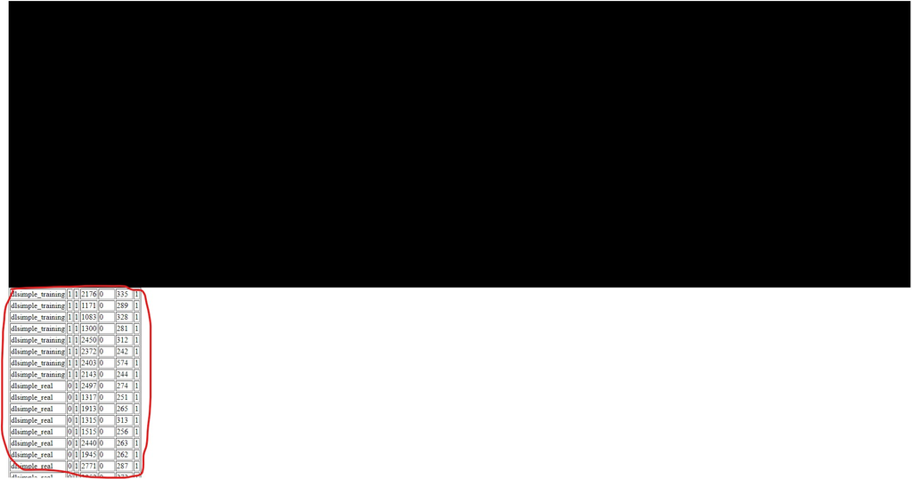

2.到文字編輯器貼上並編輯標題，再另存檔案

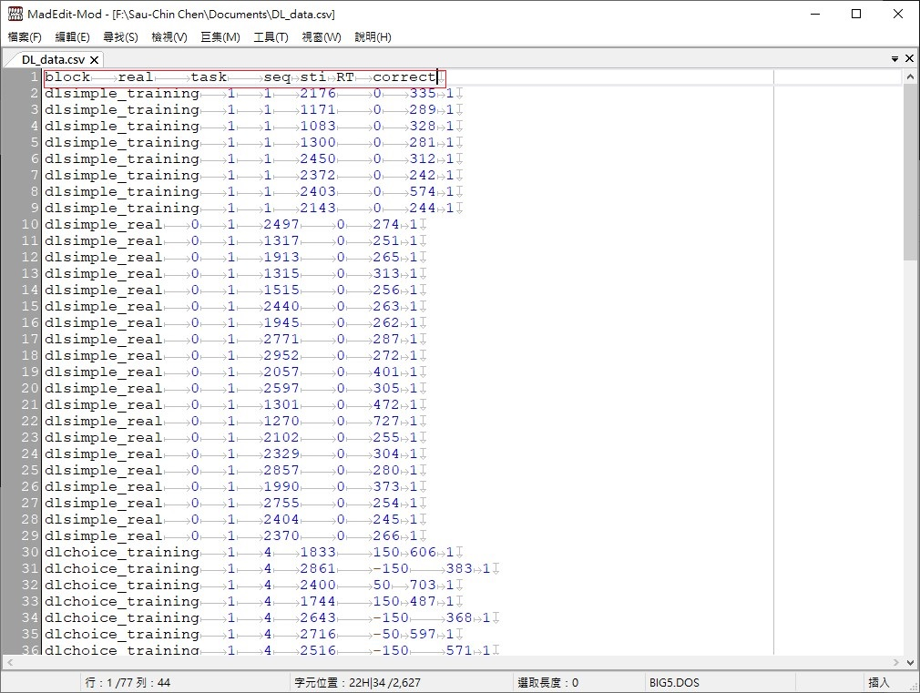

3.使用JASP / jamovi處理資料

## Stroop作業

[figure not shown]

- 親自體驗
- 測試結束的資料欄位

| block | word | color | contigency | key | correct | RT |
| --- | --- | --- | --- | --- | --- | --- |

## Simon作業

[figure not shown]

## Flanker & Motor Priming

- 親自體驗
  - Flanker task

  | stimuli | condtion | correct | RT |
  | --- | --- | --- | --- |

  - Motor priming

  | probe | target | condtion | correct | RT |
  | --- | --- | --- | --- | --- |

## 追本溯源

- 檢視Zwaan et al. (2017) 再現的[三項知覺實驗](https://osf.io/5hxge/)，與原始研究的假設及方法的差異。
  - Craft and Simon (1970) 的[Simon task](https://osf.io/jt2k3/)
  - Eriksen and Eriksen (1974) 的[Flanker task](https://osf.io/v4xtp/)。
  - Eimer and Schlaghecken (1998) 的[Motor Priming](https://osf.io/9y7ak/)

## 知覺實驗的模擬分析

### 以源始版Simon作業為例

- 解析原始研究的資料收集程序
  - 整理符合原始研究設計的模擬參數
  - 以最佳考驗力預估獲得相同發現需要的樣本數
  - 計算單一參與者貢獻的資料數值及數量
- 運用模擬函數虛擬可分析資料
  - 製造多位參與者的原始反應時間及正確與否
  - 運用原始研究計算方式總計分組樣本分佈
- 分析模擬資料

## 速度與正確率互補

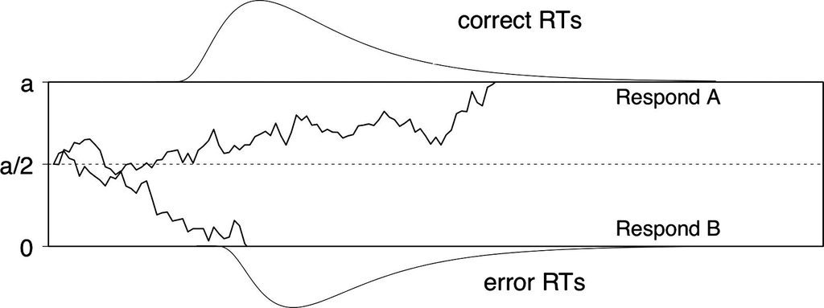

## Psytoolkit實驗腳本製作

- [腳本製作筆記](https://hackmd.io/@CSC/S1WIz64IE)

## 效果量-考驗力-樣本數

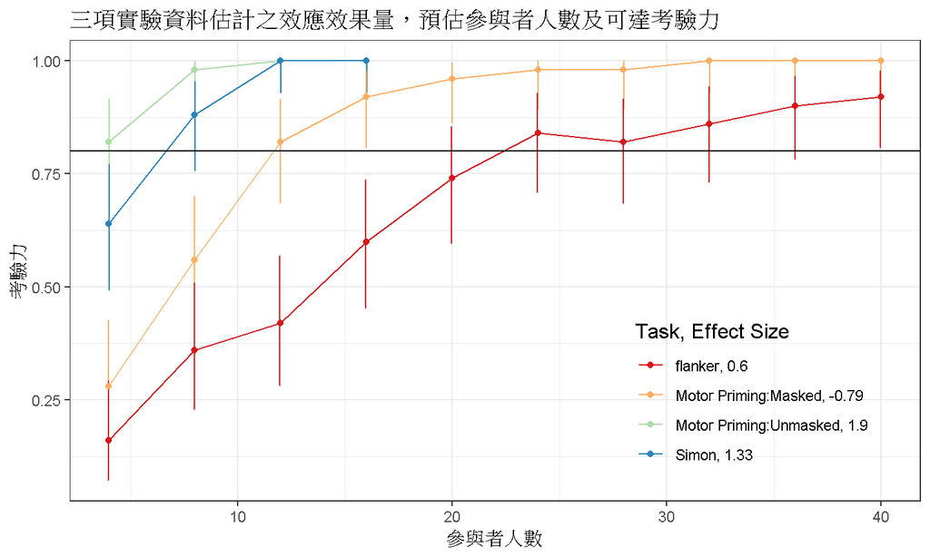